# Blog

Rennlo VL Mileas

## About

There are interesting and consequential societal questions in the contemporary dialogue. It is hard to have a calm and fruitful conversation about these topics across the political division. The challenge stems partly from the emotional load and incompatible underlying assumptions and definitions associated with the phenomena.

The aim of these writings is to offer tools to structure thinking about the questions. The intention in most of the writings is not to guide the reader towards a certain political view, but rather to help improve understanding about the questions. In order to avoid shouting past each other in the public conversation, it is necessary to pinpoint first where the root of the disagreement lies.

A commonly accepted conceptual framework, a model in other words, can help us build a common ground for the conversation. A good model is flexible enough, so that it can be bent and twisted to accommodate different opposing views. The model can then be used to communicate thoughts more clearly, observe what follows from different underlying assumptions, and find out what kind of results can be expected in the aftermath of a societal change. Keep in mind the famous quote by Box “All models are wrong but some are useful”.

# What is a Woman?

February 2023

The concept of gender, what it means to be a man or a woman, has recently become a topic of public debate. Sex specific gender roles have traditionally been metrics of judgement, for determining whether a male is a “real man” or whether a female is “womanly”. A feminine man was still considered to be a man, but not a very good one. Critics suggest that these gender roles are largely a product of social construction, and that the concept of gender should be redefined and detached from biological sex. The gender of a person should be merely based on the social behavioral patterns and norms that feel natural to that person, regardless of their sex. Under this new definition, a male who resonates with the social role and appearance of a woman, is a woman. The public conversation about the topic often fails painfully. The progressives act as if their favorite re-definition of gender has already been societally established, spouting statements like “men can get pregnant”. The conservatives, who still consider the words “man” and “male” to be synonymous, can’t believe how someone could be so deranged. The aim of this article is threefold. 1) I propose a model, which helps different sides of the argument avoid talking past each others. 2) I outline three possible pathways forward, of how to define or re-define gender. 3) The model enables following through more clearly, what do the different underlying assumptions regarding the biological connection between sex and gender, or lack thereof, entail for different suggestions moving forward.

### Introduction

We create concepts (definitions and categories) to simplify the endless complexity of the world, in order to understand, communicate and function successfully in it. Most of our concepts are imperfect in the sense that they leave something relevant out, or overlap with other categories. Try providing an all-encompassing and exclusive definition for the concept of “chair”, or an exact cutoff when a “puddle” become a “pond”? Such definitions are prone to be either imprecise, arbitrary, circular or void of meaning. Yet we can still identify most of the chairs and ponds.

The main justification for a category depends on its usefulness. Consider the Gregorian calendar, which is an imperfect categorization of time on planet Earth. It is imperfect in the sense that any discrete number of days doesn’t exactly match the time it takes for Earth to revolve around the Sun. A day has to be removed from the calendar on those years which are divisible by four but are not divisible by 100, unless they are also divisible by 400. Even this is not enough to make the calendar perfect, as unpredictable astronomical events impact the calendar, requiring ad-hoc fixes in the long run. Even so, having a common calendar which works most of the time is so useful that we accept it regardless of its epistemic imperfections.

The question “What is a woman?” is not decidable by science. It is a matter of definition. It is up to us as a society to decide how we wish to define the concepts we use. Some concepts are more useful than others. Sciences can help us anticipate how useful a new concept would be. For example, biology, sociology, psychology and other fields can shed light to the relative share of influence from nature and nurture on our behavior. This helps assess to what degree are gender norms social constructs.

The concept of **sex** is determined on the level of biology, based on one of two reproductive roles: A person with XY-chromosomes and small reproductive cells is a male, and a person with XX-chromosomes and large reproductive cells is a female. It is the general potential of a certain biological machinery to produce large reproductive cells, instead of small ones, which determines that it’s a female. Therefore this definition can still hold, even if a particular female lacks the ability to produce large reproductive cells or give birth. This categorization applies to most of the mammalian species, and most of the individuals within a species. There are some inter-sex humans, who don’t clearly align with either of the categories, but they are very few in number. Because of its broad applicability, sex is considered a binary dichotomy.

Traditionally the defining character of **gender** has been biological sex: A woman is an adult human female and a man is the male counterpart.

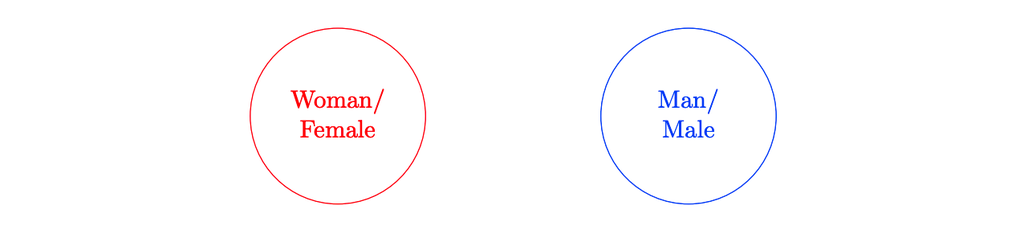

Figure 1: Traditionally the concept of gender has been attached to biological sex

Critics like Judith Butler point out that this is an incomplete description of how the words “man” and “woman” are actually used in practice (see for example Butler 1988). Much of what is considered “manly” or “appropriate for a woman” seems to relate to social patterns of behavior. Having male genitals is not enough to be considered a “real man” - it requires also an adequate success in performing the role of an ideal man. Hence, the biological sex seems to have only been the necessary but not sufficient condition for what constitutes a man or a woman.

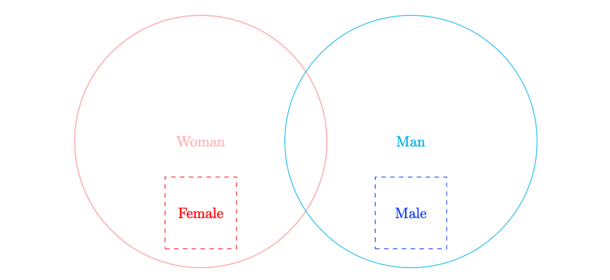

Figure 2: According to some critics, the concepts of man and woman mostly include performative social aspects that don’t root to biology. Biological sex has only been the necessary but not sufficient condition for gender, which it needn’t be anymore.

It is important to note, that these social aspects related have historically not been part of what determined the gender of a person in the West. Instead, the social roles functioned as criteria, based on which males and females were judged as representatives of their sex. If a male performed his role as a man inadequately, it impacted how much societal appreciation he garnered as a man, but not whether he was considered to be a man or a woman.

Every person has a mixture of feminine and masculine traits, emotional responses and behavioral tendencies. These social patterns are not fully determined by biological sex, which is evident from the variation of these traits within both sexes; there are for example plenty of feminine males and masculine females.

But in that case, is biological sex needed as the necessary or any kind of condition for the definition of gender? Should we re-define gender purely in terms of behavior? The next section develops a model (a conceptual framework) for thinking about this question.

### Model of Sex and Gender

Consider the feminine-masculine -spectrum. It describes a simplified landscape of personality, social behavior, physical traits and emotional experiences. Every person $i\in\{1,\dots,N\}$ has a unique mixture of feminine and masculine features, and thereby is located on that spectrum. Every person also has a binary sex $s \in \{f,m\}$. The locations on the behavioral feminine-masculine spectrum are drawn from the sex-specific probability distributions, characterized by the probability density curve $X_{if} \sim \mathbb N(\mu_f, \sigma_f^2)$ for females and $X_{im} \sim \mathbb N(\mu_m, \sigma_m^2)$ for males, where $\mu_s$ is the mean and $\sigma_s^2$ the variance. Whether these distributions differ due to biology or social conditioning is touched upon in the next section.

Let there be an ideal of a man $\lambda_m$ and a woman $\lambda_w$, to which every male and female, respectively, is compared to.

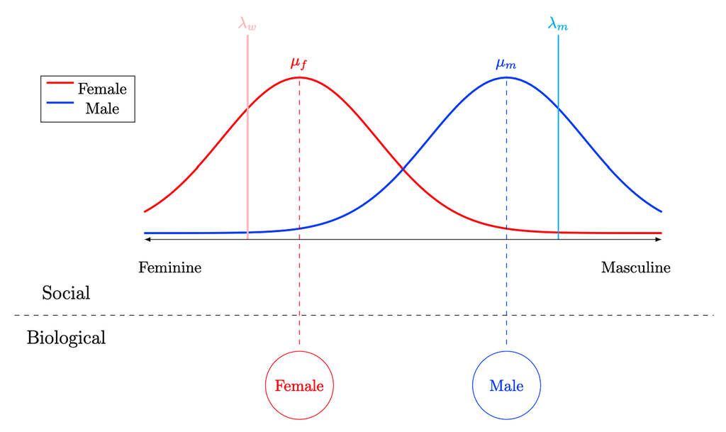

Figure 3: The concept of gender has been traditionally defined based on biological sex and every person’s worth is measured against an ideal of their gender. The female probability density curve of social traits is depicted in red and the male density curve in blue.

The sexes are encouraged and pressured to act according to their respective gender roles, encapsulated in the respective ideals. Males ought to be masculine, stoic and competitive, whereas females ought to be feminine, caring and motherly. Failure to comply with the norms associated with one’s sex does not change the gender, but incurs social costs.

The closer a male is to the ideal man, $|X_{im}-\lambda_m|$, the better of a man he is considered to be. An ideal is a motivator and a judge at the same time. The further a male falls short from the social demands of an ideal Man, the worse of a man he is considered to be. Likewise, a female who can’t or won’t perform the role of an ideal Woman, can be deemed a lesser woman, but still a woman.

The aggregated discomfort with the traditional definition of gender and the ideals $\lambda_f, \lambda_m$ can then be conceptualized for example in the following way
$$\begin{align*}
L &= \sum_{g\in\{f,m\}}\sum_{i=1}^N (X_{ig}-\lambda_g)^2
\end{align*}$$

This simplistic utility calculation is not the be taken as a theory of human flourishing, but instead as one way to think about one aspect of a social topic.

This model is a simplification. It is possible to exert both feminine and masculine traits strongly at the same time. This feature is easy to take into account. The conceptual analysis can be extended by letting both masculine and feminine features vary freely, creating a two (or any) dimensional plane instead of a line. Extending the model in this manner is not necessary, as it would not change the main results.

However, we do need to add a new dimension into the model to be able to asses, under what circumstances it makes sense to detach the concept of gender from biology. This new dimension determines the relative impact of nature and nurture on gender-related issues: To what degree are those behavioral and emotional aspects influenced by the biological sex, which seem to comprise the gender identity?

#### Nature vs Nurture

Psychometric studies have found gender differences in life preferences and personality traits. This means that the expected values for sex-specific behavioral distributions differ, $\mu_f\neq \mu_m$, as indicated above in the figure. In other words, an average male differ from an average female in terms of behavior, on the masculine-feminine axis. It is unknown to what extent this sex-difference in averages is explained by genes and to what extent by culture and upbringing.

Let the means of the sex-specific behavioral distributions depend on the biological and social influence
$$\begin{align*}
\mu_f &= B + \alpha B_f + (1-\alpha) S_f \\
\mu_m &= B + \alpha B_m + (1-\alpha) S_m
\end{align*}$$

where $\alpha\in[0,1]$ issues the relative importance between biological sex and social influence on human behavior. The general impact of human biology on behavior is given by $B\geq 0$, whereas $B_s, S_s \geq 0$ issue the sex specific influence from biology and social programming, respectively.

Consider an important and ethically relevant thought experiment: What would happen to these gender differences $\mu_f\neq \mu_m$, if the social and cultural impact on human behavior was minimized, $S_f=S_m=0$, and only the impact from biology $B,B_f,B_m$ would remain? Put differently, what is the causal impact of biological sex in particular on the behavioral patterns $\mu$ of a human, if any? The equation becomes
$$\begin{align*}
\mu_f &= B + \alpha B_f \\
\mu_m &= B + \alpha B_m
\end{align*}$$

Let us go through two opposing hypotheses explaining the gender differences, where 1) biological sex has a negligible $\alpha=0$ or 2) a strong $\alpha=1$ impact on behavioral patterns $\mu_f, \mu_m$.

**Hypothesis 1: Strong nurture position.** Biology doesn’t influence behavior much at all $\alpha \approx 0$. The gender roles have mostly resulted from social construction $S_f\neq S_m$ and bare minimal connection to biology. Then, by definition, the sex difference in gender expression would disappear, $\mu_f = \mu_m = B$. However, the value of $\mu$ and the shape of the distribution could still be influenced by other biological factors B, shared among both sexes.

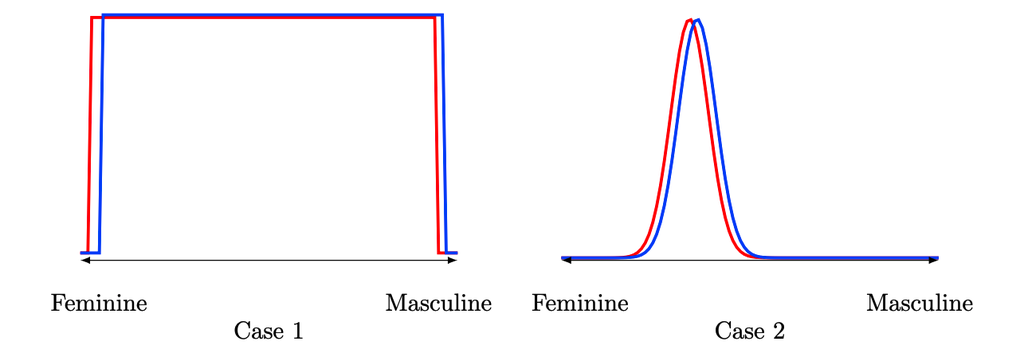

Figure 4: According to the strong nurture position of hypothesis 1, biological sex doesn’t predict gender identity at all. This could mean that humans are blank slates $B=0$, case 1. It is also possible that people have behavioral proclivities driven by biology B, but those proclivities are not based on sex, as in the case 2.

Under hypothesis 1, human behavior $\lambda_f, \lambda_m$ is bifurcated into sex specific patterns only due to social construction $S_f \neq S_m$. It can then be argued that there is no apparent reason to continue demanding a specific sex to exclusively function according to one set of behavioral and emotional patterns.

**Hypothesis 2: Strong nature position.** Gender differences are strongly re-inforced by biological sex, $\alpha \approx 1$, if $B_f \neq B_m$. Then, in the absence of social influence, the sexes would revert to their natural distributions of social patterns. These two distributions can still exert variation because of randomness, meaning that not everyone has to be identical with others of their sex, even if gender differences were purely biological.

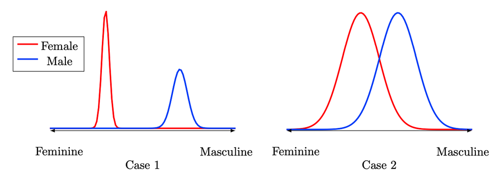

Figure 5: Under the strong nature position of hypothesis 2, the male and female social patterns differ also in the absence of social influence. The impact from biological sex can be strong or weak, as in cases 1 and 2, respectively.

If biology strongly influences the behavioral and emotional patterns of individuals, then the gender differences are manifestations of the sex differences, and not (purely) social constructions. That is, biological males could embody more masculine traits on average than biological females, even in absence of traditional upbringing. This does not mean that the current gender ideals $\lambda_f, \lambda_m$ are optimal, but it does make it plausible that gender ideals should be sex specific; $\lambda_f \neq \lambda_m$.

Another related consequence of hypothesis 2 is that a 50-50 distribution would be the wrong benchmark for equality on many domains. This is because males and females might choose differently based on their innate differences in average preferences and personality. We might falsely attribute these differences in average choices to systemic distortions in the society. It might also be harmful for example to push women to adopt more masculine traits, if they on average resonate more with the feminine traits.

In case $B_f = B_m$ under hypothesis 2 $\alpha\approx 1$, then the situation is similar to that of the Figure 4, where the behavior was only impacted by non-sex related biology B.

The analysis can be differentiated further. The sexes might have a different proclivity to respond to social pressure, $\alpha_f \neq \alpha_m$. Both social and biological aspects might also impact the variance of the distributions $\sigma_f^2, \sigma_m^2$. It is also quite commonly accepted that humans are outcome of both nature and nurture, so neither hypothesis in the extreme form is likely to be true.

### What to do?

There are broadly three paths forward: A) Detach gender from sex, B) continue as before or C) loosen gender boundaries. I use the model developed in the previous section to make predictions of what would likely be the consequences.

#### A. Detach gender from sex

If the content of what defines a gender of a person is mainly social, low $\alpha$, then upholding the link between sex and gender might alienate many. As a remedy, we could re-define gender purely on the social level, diminishing the role that the sex of a person plays in human cooperation.

Removing the link between gender and biological sex would then mean that a person who finds resonance with the role of a woman could declare to identify as that gender, regardless of the underlying biological sex. As everybody would be compared to that gender ideal which is closest to them, $\lambda_W, \lambda_M$, then the societal discomfort from falling short of an ideal would become
$$\begin{align*}
L^B &= \sum_{g\in\{f,m\}}\sum_{i=1}^N
(\min\{X_{ig}-\lambda_W, \ X_{ig}-\lambda_M\})^2
\end{align*}$$

It might be the case regardless of whether hypothesis 1 or 2 is closer to truth that this option A would reduce societal discomfort stemming from rigid sex-based gender roles.

Special attention need to be used in separating the terms describing biological sex and social gender. For example, a male could identify as a woman, but a male could not identify as a female. It would still be impossible that a person with XY chromosomes could change them to XX chromosomes.

Gender doesn’t need to be a binary variable anymore, as it’s defined as a range on a continuum. Those who don’t fit into either of the gender categories could be characterized as non-binary. Alternatively, new gender identities could be defined for specific combinations of masculine and feminine traits, which don’t reflect the typical man or woman. The categories don’t have to be rigid either, they can adjust to take whatever form those identifying in the category choose to identify as. Consider a scenario, where k new genders and their ideals are designed to minimize the feeling of being an outsider for most of the people
$$\begin{align}
\min_{\lambda_1, \lambda_2 \dots \lambda_k} L^{B_k} &=
\sum_{g\in\{f,m\}}\sum_{i=1}^N (\min\{X_{ig}-\lambda_1, \
X_{ig}-\lambda_2, \ \dots, \ X_{ig}-\lambda_k\})^2
\end{align}$$

If gender is purely a social construct, $\alpha=0$, then the gender ideals could be changed deliberately. Social movements and the entertainment industry tend to depict people in a certain light. Consider a period where females are systematically cast in masculine roles. This can be interpreted as an attempt to move the benchmark of ideal woman in the masculine direction towards the ideal man $\lambda^w=\lambda^m$.

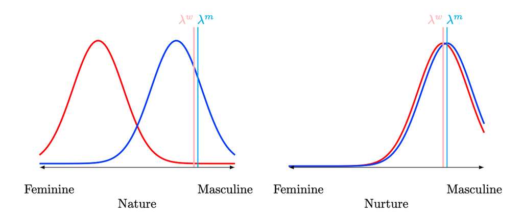

Under the nurture hypothesis, this would be expected to cause a large shift in social behavior towards the new ideal - females becoming less feminine and more masculine. Because there was no basis for females to prefer femininity, the change would be psychologically neutral for females.

The situation would be different if there was some truth in the nature hypothesis, $\alpha\neq 0$ and $B_f \neq B_m$. If the new socially manufactured gender ideals are very different from the biological reality, it could increase aggregate discomfort. Females who still find themselves resonating with the feminine would feel estrangement for falling far from the new and more masculine ideal for women. Some females might adopt masculine feature due to social pressure, when $\alpha < 1$ and $S_f \neq S_m$, but feel dis-aligned with themselves. It is also difficult to promote masculinity for females without implicitly setting femininity as of secondary value. It probably has a de-stabilizing societal impact, if masculinity is raised above femininity for everyone as an ideal.

The aim of this re-definition scheme is partly to reduce exclusion - to let everyone feel that they belong to the category of their choosing. One of the trade-offs with this solution is that it becomes comically hard to answer basic questions like “what is a woman?”. A category necessarily includes something and excludes something else. If only those are excluded who don’t want to belong to the category, then the category can only be described using self-reference - “a woman is what people identifying as women identify as”. It is not clear what is being talked about. Dismantling functional categories can also have all kind of secondary effects. We need structure to function as human beings. Oftentimes even imperfect structure is better than no structure. Dismantling the foundations of human identity can leave many people puzzled and lost. There is also a linguistic complication with those languages, which have gendered pronouns.

#### B. Continue as before

Continue to uphold sex specific behavioral patterns and encourage individuals to pursue the roles that match their sex. This could be justified by claiming the usefulness of gender roles. Perhaps gender is a useful software on top of the hardware of sex, which the culture has managed to find over long search time of trial and error. The rather autistic utility calculations for the societal discomfort, $L, L^B$ and $L^{B_k}$, don’t say anything about the benefits of the gender categories for individuals and the society. It could be very useful to have guardrails that softly guide for how to live midst the endless complexity of life, like an informed prior.

The notion that some aspects of gender are socially constructed does not mean that all of it is socially constructed. And even if something is socially constructed, it is not necessarily arbitrary, as there can be limitations to what kind of social constructs are possible or durable. Further, even an arbitrary social construct can be useful. Take for example the location of a pharmacy. It is not important where it is placed, the usefulness stems from it existing somewhere in the neighborhood - anywhere.

#### C. Broaden gender boundaries

The gender categories can be kept binary and sex-specific, but adjusted to accommodate more people. Modifying the model in Figure 3, suppose there are regions on accepted behavior around the gender ideals. Inside of these regions all social performances are considered to be normal and acceptable for that gender. If someone is located outside of this region, they are frowned upon. Perhaps in the past these regions were too narrow, causing many people to find it hard to resonate with either of the genders.

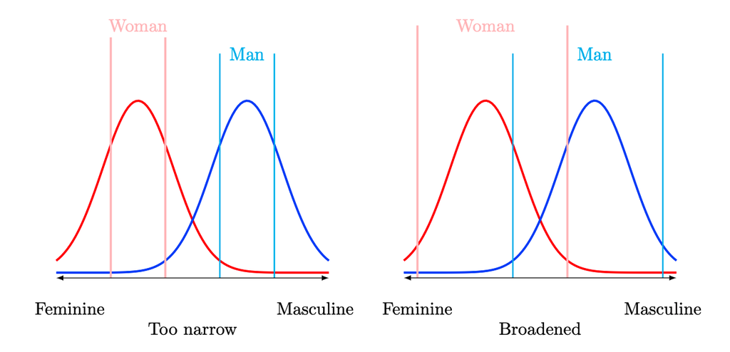

Figure 6: Option C: Loosening the normative social requirements for genders allows more people to express themselves freely, without clashing into the boundaries of their gender.

After the broadening of social expectations, the gender categories now overlap, meaning that it is not considered unusual to be a masculine woman or a feminine man. The gender is still determined based on biological sex, but for most people it doesn’t restrict their ability to function in the way they resonate with. A male is a man, but has the freedom to express his manhood in almost whatever way he sees fit.

Recall the option A), where more gender identities emerge to satisfy the particular needs of individuals. The logical conclusion for making no-one excluded is to craft a unique gender identity for every individual, $k=N$. But this would be similar in effect to forgetting the concept of gender altogether and leaning more heavily on individualism - regardless of your gender, you can act how you please as long as you don’t harm other peoples’ possibility to do the same. This is the spirit of classical liberalism, the political movement that arose from the Enlightenment philosophy. This is the direction we’ve taken in the West, further than other cultures that currently exist and further than most cultures of the past. Perhaps inclusivity is better served by creating less specific instead of more specific gender norms. This is the crux of option C.

The furthest we can go on this path is to widen the regions of acceptable gendered behavior to include all people. If hypothesis 1 of $\alpha\approx 0$ is true, then the importance of biological sex would be expected to diminish because of its societal irrelevancy, in the same way as hair color or left/right -handedness. If hypothesis 2 with $\alpha\approx 1$ holds true, we shouldn’t expect a drastic change - most males and females would still behave in much the same way as before the change in gender-norms.

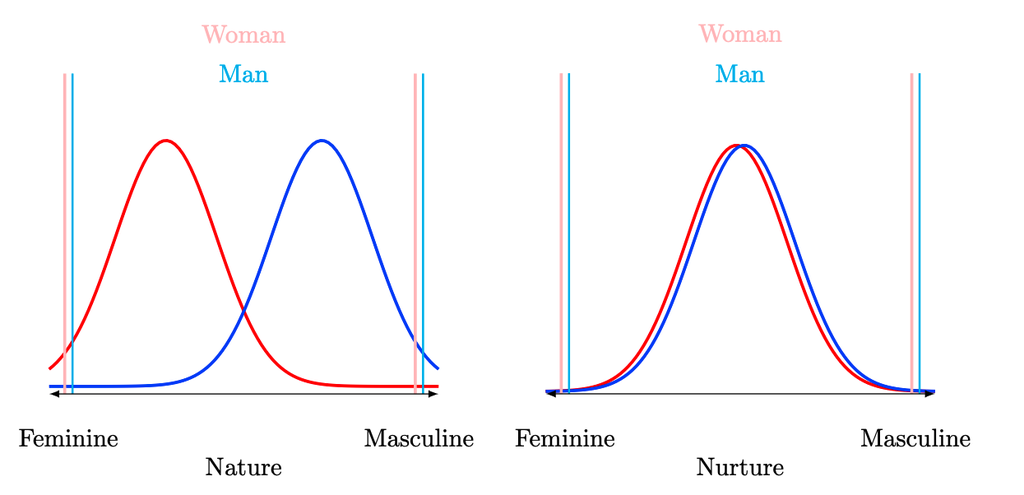

Figure 7: Widening the gender categories to include all behavioral patterns, identically for men and women.

The psychometric gender differences regarding preferences and personalities seem to remain in Nordic countries, even after the boundaries have broadened substantially. This suggests that the nurture hypothesis 1 doesn’t hold, at least in the strong formulation of $\alpha \approx 0$.

### 5. Conclusion

We are free to create and use whatever concepts and categories we please. It would be perfectly coherent to define everyone with a brown hat as women and others as men. Some concepts are more useful than others. A categorization doesn’t have to be perfect in order to be useful. Categories always include something and exclude something else. A category that includes everything is not useful. Science can in some cases help us rank the usefulness of competing categorizations, but can’t objectively help us pick one.

There is an ongoing debate regarding the need to re-define the concept of gender. More specifically, some critiques argue that biological sex is not needed in the definition of a gender identity, but rather it should harness its meaning solely on the social level of emotional and behavioral patterns. This opens up the possibility to craft new gender identities and make their criteria malleable. At the same time, it becomes comically hard to provide any meaningful definition of what it is to be a woman.

The aim of this article is to suggest a model for thinking about the connection between sex and gender, or lack thereof. Using the model, I go through several options for how to proceed.

I suggest the Option C, where the definition of gender is kept tied to the biological sex, but the judgmental social pressure on how to perform the role of the given gender properly is loosened up, to leave more space for people to express themselves as they see fit, without the need to impose confusing and contrived changes to the linguistic domain.

# Trans-Women in Sports

June 2023

### Introduction

A complication arises, if we accept the Butlerian separation of gender from sex: Should biological males identifying as women compete in women’s sports? Women’s sports is a protected class set up to increase the representation and possibilities of female athletes. Trans-women have gone through puberty as males, where the elevated testosterone accumulated them more muscle mass, larger skeleton, stronger joints and tendons, and increased bone density, with respect to someone with a female puberty. In many sports this gives males an advantage over females, even if they lower their testosterone later on with pharmacological treatments.

But men and women are on many regards more similar than different, as there are larger differences within sexes than between the sexes. As a consequence, this also creates an unfair advantages for some individuals over others of the same sex. Does it therefore matter if a trans-woman has an advantage over some females, if the playing field is not level to begin with?

I demonstrate how even small differences in athletic prowess between an average male and female can lead to large differences between the male and female pro athletes. The consequence of this statistical property is that at the extreme, which pro sport is by definition, the male advantage is in many sports very large.

### Differences exaggerate at the extreme

Consider a case, where an individual’s athletic prowess is drawn from sex-specific probability distributions, $X_{if} \sim \mathbb{N}(\mu_f, \sigma_f^2)$ and $X_{im} \sim \mathbb N(\mu_m, \sigma_m^2)$, where $i\in\{1,\dots,N\}$, $N_f=N_m$, $\mu_m>\mu_f$ and $\sigma_m>\sigma_f$, and $\{f,m\}$ denote for female and male sex, respectively. An athlete is someone with an athletic prowess greater than 98 % of the sex. The male and female cutoffs for athletes are depicted by dashed lines in Figure below.

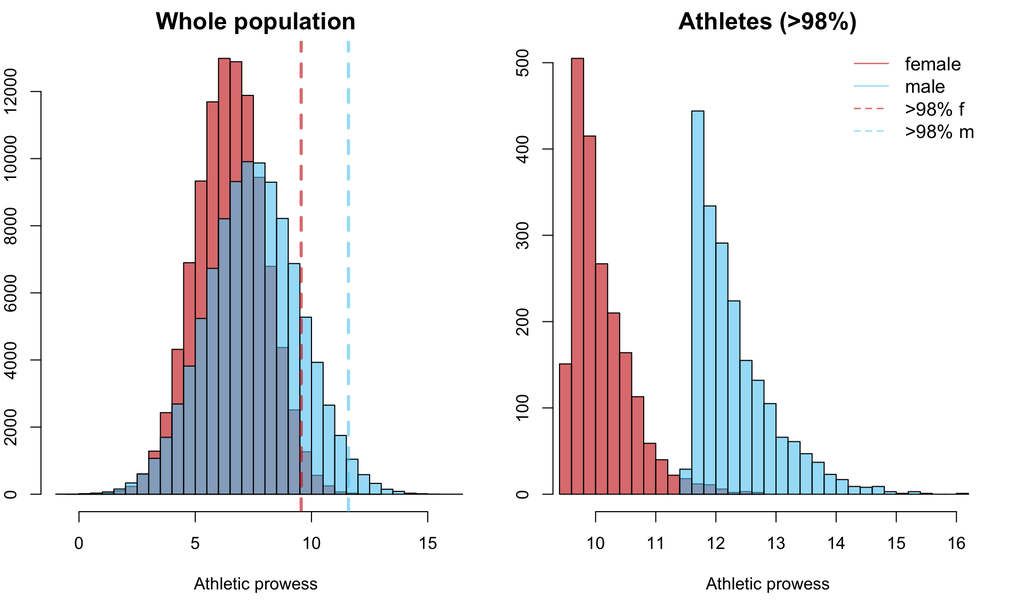

On the left a large overlap can be seen in the athletic ability between the male and female populations, but the gap widens on the right when only the top 2 % of males and females are compared.

Even small differences in expected values and variances between two largely overlapping populations (males and females) can translate into large differences at the extremes. There are many females who are stronger than many males, but for example at the elite level of powerlifting there are virtually no females who are stronger than any of the males. When it comes to combat sports, the stakes don’t only include winning and losing, but also potentially serious health consequences due to the mismatch.

If we were to abolish gender divisions and choose the best 2 % of the whole population as athletes, more than 97 % of the athletes selected would be males.

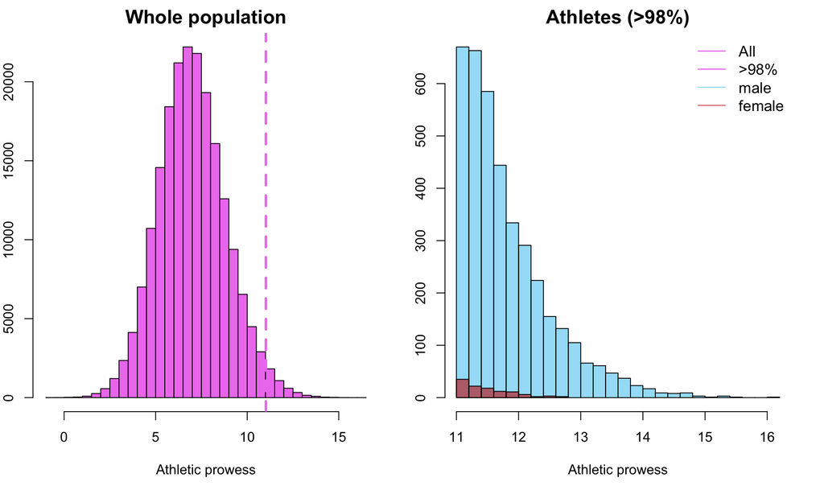

Therefore, it’s clear that under quite moderate assumptions, having gone through a male puberty gives a much stronger advantage in the women’s sports, than being a genetically exceptional female outlier.

### What to do?

1. Include trans-women in women’s sports, which would be unfair to women.
2. Create a separate class for trans-athletes. This would lead to very small participation numbers, hindering the excitement.
3. Re-brand the protected category to be for female women only and create an open class for everyone else. This would be unfair to both trans women who typically have a medically lowered testosterone and trans men who lack the male puberty, both competing against male men. Regardless of the choice, someone has it unfair, especially trans-men athletes in most of the scenarios.
4. Another way to approach the problem would be to abolish the gendered leagues altogether and come up with new metrics based on bone density, lean muscle mass, lung capacity or other relevant markers to craft fair and competitive leagues for different sports. This might be impractical and would likely leave female athletes with a lesser spotlight, as demonstrated in the second simulation above. Also, the hypothetical end result of this solution would be to control for all aspects which influence performance in a given sport, so that the differences in performance are either non-existent or down to randomness. This could sound like a strange end result to many sports fans.

# Can We Reduce the Number of Incels?

March 2023

### Introduction

There is a group of males who live in involuntary celibacy (incels), without being able to fulfill the basic human desires of having sex, being touched, or feeling accepted. For some people this predicament can continue for years, driving them deeper into isolation, resentment and in rare cases even into violence.

There are two competing hypotheses explaining the emergence of the incel phenomenon. The quality hypothesis underline the lack of attractive qualities in the incels, and the rank hypothesis focuses on the changing norms on the mating market. The crucial difference between these approaches boils down to the underlying core issue: How do men and women choose sexual partners?

**Quality hypothesis:** Assume that men and women both only consider a candidate partner’s perceived level of quality when choosing a short term mate, and not at all how the candidate compares to other people in the reference class. Then it seems that the predicament of incel men must result from their lack of social and emotional skills, hygiene, success and because of their misogynistic worldview. Perhaps their lack of female attraction is a consequence of, rather than the reason for their personal shortcomings and resentful misogynistic ideology. If only these particular incel men would improve their shortcomings adequately, the whole incel phenomenon would vanish, and almost no one would be left in long term celibacy against their wish.

**Rank hypothesis:** Now consider the possibility that particularly females not only consider the quality, but also the rank of the candidate in the male hierarchy: How does the candidate compare to other males? This mating strategy is called hypergamy in the sociological literature. It is then possible that the incel phenomenon was born as a consequence of a shift in social norms governing sexual behavior. More specifically,

1. sex was detached from the marriage and it was no longer required to occur only under monogamous social arrangement. A new dating marketplace emerged, which set free
2. the hypergamyous mating habits of females, i.e. the tendency on average to choose partners who are higher than them in the socioeconomic ranking, and
3. the promiscuous mating habits of males, making those with options capitalize on the overflow of female attention. Male promiscuity broadens the reference class of potential partners for every female, in which the males are ranked.

This combination of three factors allows females to pick and share higher quality mates for short term dating, without someone’s luck being another one’s loss. For males, this creates a highly unequal Pareto distribution of sexual success. The rank of a male is expected to influence the female choice with an unknown weight $\alpha \in [0,1]$ relative to the quality of the male.

In this writing I take an agnostic view on what holds true, and instead consider the societal impact of the following intervention under the quality and rank hypothesis: The quality of every current incel man is improved at least up to the level of the first non-incel man. If the quality hypothesis holds true, this should fix the problem. But if the rank hypothesis is correct, even if all current incels improved their relevant qualities and ended their celibacy by the intervention, the new bottom of the male hierarchy would then be cast into involuntary celibacy.

Before continuing, it is important to undermine that acknowledging a phenomenon doesn’t have any connection to moral judgement about that phenomenon.

### Model

Every person in the model has a level of quality (one number) that reflects their combination of social and emotional skills, personal hygiene, earning prospects, physical attributes, intelligence etc. This quality is drawn randomly for a person from a sex specific normal distribution
$$\begin{align*}
Q_{im} \sim \mathbb N(\mu,\sigma_m^2) \\
Q_{iw} \sim \mathbb N(\mu,\sigma_w^2)
\end{align*}$$

where index i stand for the individuals $i \in N^m, i \in N^w$, m and w denote for the gender of the individual, and $N^m=N^w=:N$ is the population size of the given gender.

The quality of an individual determines his/her likelihood of meeting potential partners. Someone with good social skills and an attractive face probably ends up on more conversations and dates than someone lacking on those respects. The likelihood that the man i has an encounter with the woman j is defined as the product of their qualities $Q_{im}Q_{jw}$, where higher qualities increase the likelihood. An encounter can be a short chat, date or a friendship. We combine the encountering likelihoods between the man i and all of the women with $Q_{im}(Q_{1w}+Q_{2w}+\dots+Q_{Nw})$. Due to the calibration of the model, this number varies between a zero and a couple of thousands. It can be interpreted as a number of encounters with the opposite sex over the active dating age of a decade or so.

Every man also has a relative ranking among all men, $R_{im}=\{1,2,\dots N\}$, defined by the rank order of their quality $Q_{im}$.

Some fraction of the encounters leads to sex. The central question of this writing relates to this fraction. Under the Quality hypothesis, the fraction is constant $\gamma>0$ for everyone. Under the Rank hypothesis, the rank of the man i impacts the chances that an encounter leads to a romantic match, $\gamma_i>0$.

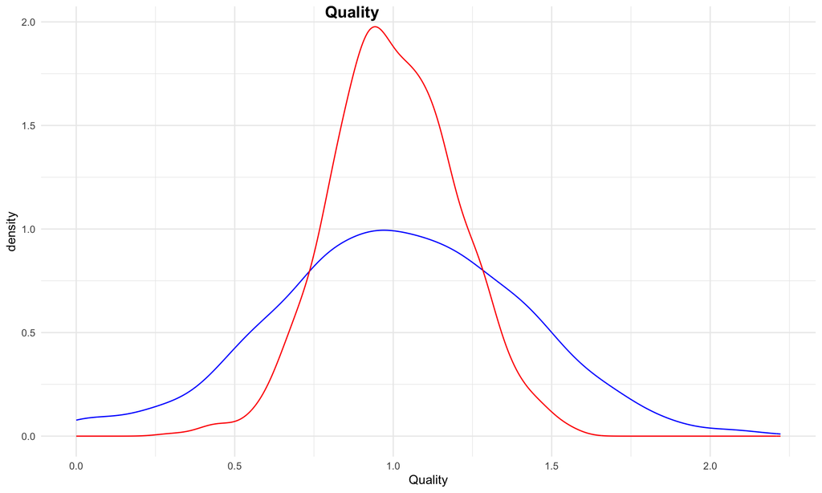

Qualities and meeting likelihoods of men (blue) and women (red)

**Quality hypothesis:** Under this hypothesis the number of sexual and romantic experiences $S_{im}^q S_{iw}^q$ for every man and woman only depends on their quality. The upper index q stands for the quality hypothesis. The number of successful sexual encounters is calculated as
$$\begin{align*}
S_{im}^q &= \gamma*Q_{im} \sum_{j = 1}^{N} Q_{jw} \\
S_{iw}^q &= \gamma*Q_{iw} \sum_{j = 1}^{N} Q_{jm}
\end{align*}$$

where the success parameter $\gamma>0$ gives the fraction of encounters that lead to sex. For the simulation this parameter is calibrated as $\gamma=1/100$, yielding 10 partners on average for a woman.

In this scenario there are 0.6 % of the population with less than one sexual encounter, who are incels by definition. All of them are men.

**Rank hypothesis:** The number of sexual partners of women still only depend on their absolute qualities, as before. But for men the number of sexual partners now also depends on their relative rank $R_{im}$ in the male hierarchy.
$$\begin{align*}
S_{im}^r &= \gamma_i^{1-\alpha}*\left[ Q_{im} \sum_{j = 1}^{N}
Q_{jw} \right]^\alpha \\
S_{iw}^r &= D*\gamma*Q_{iw} \sum_{j = 1}^{N} Q_{jm}
\end{align*}$$

where
$$\begin{align*}
\gamma_i^{1-\alpha} &= \gamma \left[\frac{(2R_{im})^2}{\alpha
N^2}\right] \\
D &= \sum_{i=1}^N \frac{S_{im}^r}{S_{im}^q}
\end{align*}$$

The success probability $\gamma_i$ is a function of the rank of the man i, and it makes the rank of a man count for the female mating choice. Parameter $\alpha\in(0,1]$ controls how important the male rank is for women, relative to the quality of the man.

The equation for a woman is similar as above, with an adjustment for the change in the number of sexual encounters. This change is given by $D$, relative to the baseline of Quality hypothesis, and it is distributed equally for all women.

I will compare four cases, $\alpha\in \{1, 0.75, 0.5, 0.25\}$, where the first one a=1 corresponds to the Quality hypothesis and the rest of the cases describe increasing degrees of female hypergamy under the Rank hypothesis.

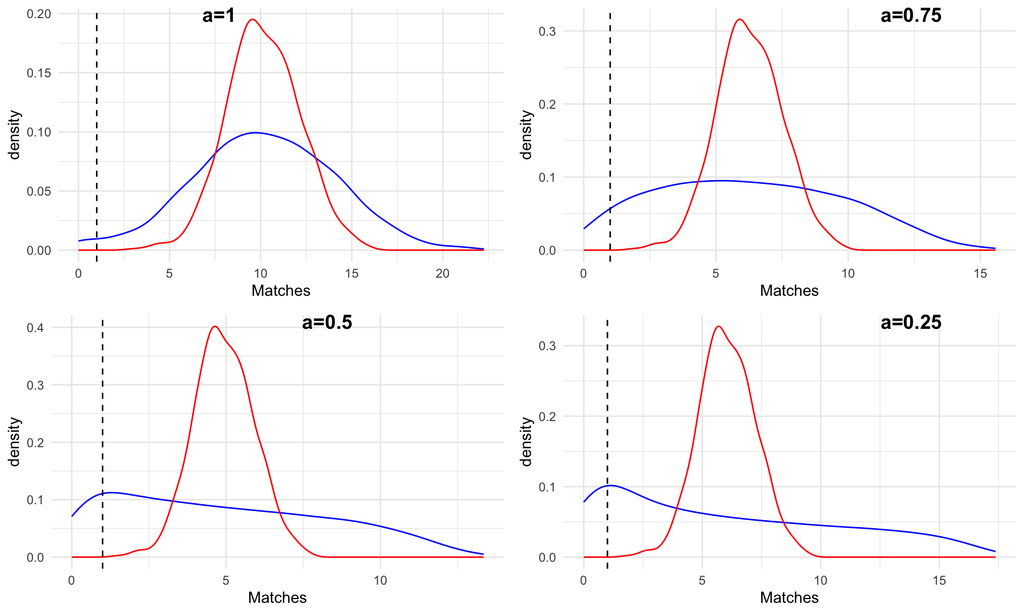

The histograms describe the distributions of the number of partners for men (blue) and women (red) in four scenarios, where only the women’s mating proclivities differ. The dashed line at 1 partner denotes for the incel-cutoff. Under the Quality hypothesis, the distribution of sexual partners reflect the distribution of qualities for both sexes. Most people have an average number of partners, with few men having somewhat more or somewhat less. Only a very small number of men are in involuntary celibacy, due to their low quality. Under the Rank hypothesis, the hypergamous tendency of women come to play with $\alpha<1$. The male hierarchy starts to look like a Pareto-distribution with $\alpha<0.5$, where some men are very successful in the dating market, whereas many men have only a little success. This pattern matches both the sociological research on hypergamy and the social stereotypes. As the influence of hypergamy increases, $\alpha \rightarrow 0$, more and more men stack at the bottom and a fewer men become increasingly successful - think of a sultan with a large harem at the extreme.

### Intervention

Consider an intervention, which improves the absolute qualities $Q$ of every incel from the worst scenario ($\alpha=0.25$, with 9.3 % incels), at least up to the same level of the first non-incel. This would include improving their job status, physical attractiveness and social skills, but the intervention also includes making their worldview less resentful. The rest of the people remain as they were.

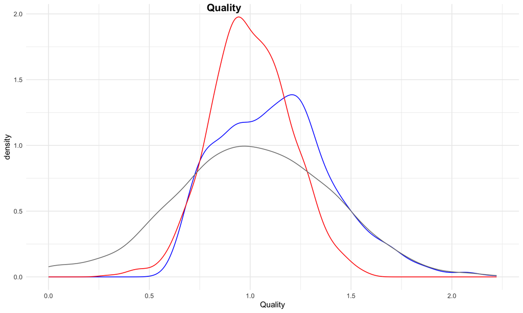

### Results

**Quality hypothesis:** The incel problem is successfully eradicated, as all men now meet the absolute standard that is demanded by women. The amount of sexual encounters increase for both sexes.

**Rank hypothesis, cases 2-4:** The impact of the intervention is less powerful, when the hypergamous tendency is present ($\alpha<1$). The incel population does not vanish, although the remaining incels are not necessarily the same individuals as before. The intervention does manage to reduce the number of incels, as long as the hypergamy does not exert too strongly, $\alpha=0.75$. But if the Rank hypothesis holds true even partly, then the incel phenomenon can’t be solved completely by only improving the quality of men. There will always be a bottom x %, regardless of how the population is shuffled. Any specific man doesn’t have to be an incel, but someone will be.

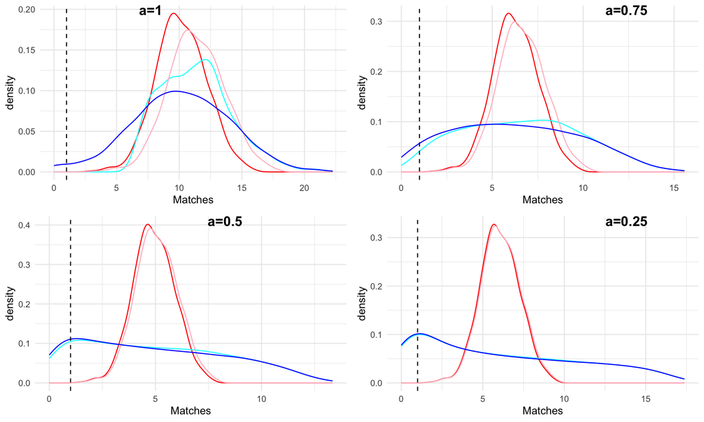

In this writing I considered the impact of a perfect intervention, in which every current man in involuntary celibacy is made more attractive to women, at least up to the standard which women currently demand from their partners. These incel men land jobs, become more hygienic, less misogynistic, more fit and develop better social and emotional skills. Many commentators have suggested a weaker variant of this intervention as a solution to the incel problem.

We find out that this intervention is very effective, if it is the case that women only choose their partners based on their qualities. However, if women also take into account the relative status of a man in the male hierarchy when choosing partners, then the intervention has only a limited impact.

Traditionally the incel problem was solved by socially upholding the norm of monogamy, by allowing sex to only take place within a marriage. This restrained both female hypergamy and male promiscuity, creating a sexual socialism of sort. The recent erosion of monogamy unleashed the female hypergamy and male promiscuity. This created a Pareto distribution of sexual success for men on the short term dating market, and as a secondary effect, the incel men stacking to the bottom of the distribution. Even though the marriage market is still broadly monogamous, the prolongued dating era prior to marriage creates a temporal period where a fraction of men are cast to incelhood.

It is not certain what ought to be done to the incel problem, if anything. Whichever hypotheses holds true, the best strategy for any individual person, incels included, is to focus on personal responsibility and try their best. But on a societal level, it is important to do cost-benefit analysis on different social contracts and to understand the impact of underlying assumptions on the effectiveness of potential policy choices. If hypergamy even somewhat describes the behavior of even a subset of women, it might mean that the incel phenomenon is unsolvable in our current social culture. In that case the deprivement of the incel men can be accepted as a necessary cost of upholding the spirit of the sexual revolution and hookup-culture. But it would then be cruel to victim blame incels, as many feminist openly does, if not to also extend some sympathy for them.

# The Problem With Modern Dating

November 2023

Modern technology has brought millions of possible sexual and romantic partners available, in principle, to everyone. With the cost of an airplane ticket, you could meet basically anyone in the world. Actually there’s no need to even move, as dating apps bring others to you. Consider the aim of finding a life companion to start a family with. How should you choose this one person out of all of the potential candidates? Before two people get to know each other properly, their compatibility is not known. The Western solution is to engage in serial dating to reveal the relevant information.

Due to severe limitations of time and effort, it is not possible to go through every partner candidate and then choose the best one afterwards. Romantic relationships are very expensive institutions, which require a lot of emotional bandwidth, time and effort. They also exert path dependency neurologically by launching a storm of addictive brain chemicals, and psychologically by establishing a status quo which can be hard to challenge. We can only date a handful of people, before having to commit the final choice. What is needed is a filtering algorithm, which selects prospective romantic partners out of the pool of all candidates.

How should we, then, choose the small subset of actual partners from among the potential ones? The prevailing strategy of the modern dating market seems sub-par. Here is the strategy in pseudocode:

1. Choose a domain: Bar or tinder
2. Choose a candidate based on sexual attraction and vibe
3. Move fast to sex. If sex is good enough, continue dating, but keep looking at the same time
4. Slowly find out about characteristics of secondary importance: Music taste, hobbies
5. If nothing too horrible comes out, begin a monogamous relationship
6. Hang out until some fundamental difference in values or goals manifests and then break up
7. Immediately continue the same procedure from step 1 onwards

Let’s go through the reasons, why this is an inefficient algorithm, akin to trying to find home from a bar following a random walk. The criticism only relates to dating with the goal of finding a life partner to start a family with. Needless to say, the following is my private take and cuts some corners.

Step 1. Problem with the typical domains in modern dating is twofold: Alcohol and lack of information. Meeting new people often includes alcohol, which reduces the ability to think and make good choices. Getting to know someone for an hour or two in a dark, noisy club while being drunk, and then going to an isolated private space alone with them for sexual purposes is a recipe for disaster. Any psychopathic narcissist can masquerade as a catch for that long. It is wise for especially women but also for men to avoid combining alcohol and sex. If you find someone attractive at a night club with the prospect of sex, just exchange numbers and see if you both still want to meet on the next day while sober. If the encounter leads to a relationship, then nothing was lost abstaining in the first night. If not, then it was probably better that way.

Many dating apps also reveal very little information about the prospective candidates. It would be better to meet people organically and get to know them as people first, before asking them out. The framework for meeting people should be chosen to maximize the chances of meeting suitable people, such as social events related to university, gym, library, hobbies, culture, etc. But alas, it is not possible for many busy professionals to organically meet enough people, so online dating might have to do.

Step 2. Many people consult their feelings religiously. We are not talking about deep emotions like love yet at this stage, but instead of surface level feels. These feelings are not objective, stable and all-encompassing truths. Many people know that their feelings can sometimes be misleading. For example, it’s possible to find someone attractive, with whom a harmonious and synergic future would evidently be impossible. It is not wise to act upon mere feelings in that situation. Feelings should be amalgamated with reason to create a powerful tool for introspection and foresight. Reason allows simulating how the future might look like with different potential candidates. These scenarios can then be evaluated by thinking how it would feel to find oneself in them. Both feelings and reason can reveal different type of deal breakers, while being blind to others. Relying on just one of them is doomed to fail.

Steps 3-5 are completely backwards. It would be more useful to introduce monogamy early on and instead delay sex. Delaying sex postpones the immolation of the storm of brain chemicals, which can momentarily override reason and skew emotions. It’s hard to evaluate whether you’re on the correct path or not, if you can’t see the path in the fog. If the partner is actually prospective for a life companion, there’s no rush. If not, the absence of sex also makes it easier to call off the relationship.

Monogamy allows the two to really concentrate in getting to know each other seriously, without making the situation unnecessarily complicated and hurtful via unuseful hedonistic multitasking. I find it unromantic and sociopathic to deal with monogamy as a contractual matter, where your undivided attention towards your romantic interest only begins after a formal agreement. When you find a real prospect, prioritize it from the beginning. If you don’t have a real prospect at hand, why engage in dating at all?

A counter argument arises: “There is not enough time to only date one partner at a time.” Firstly, The barrier to engage in a romantic relationship should be higher than “(s)he seems cute”. It doesn’t seem plausible that multiple real prospects for a life companion would emerge simultaneously, or even in the same year. Quality over quantity. Secondly, not much time needs to be dispensed in the process either. With an open and honest communication, mature adults should get an intuition about the long term prospect of the potential relationship: If it would probably end anyway after the chemical storm has past in a couple years, then it should be ended right away. It is the noisy filter, poor focus and hedonism which end up wasting time.

Speak more! It never seizes to amaze me how people entangle themselves in a web of misunderstandings, false expectations and unnecessary disappointments, just because they fail to communicate openly. Setting filthy liars aside, many misunderstandings could be avoided by replacing wishful thinking with clarity. Instead of tiptoeing around hard topics, the compatibility should be deliberately tested by seeking to engage in conversations regarding all of the deep and important subjects. The sooner a possible deal breaker comes up for either one, the better. You should want your partner to accept you as you really are. Amazingly, some people only find out after years that their preference for having kids differs from their partners’. At that point it’s hardly consoling that at least they “vibe”.

Step 6 misplaces the burden of proof. The relationship should not continue just because everything is ok. Choosing a life partner, a companion for old you and a parent to your kids, is probably the most exclusive and important choices of life. Treating partners as placeholders to dispel insecurity or boredom would make dating a very expensive hobby. It is unromantic, if the choice to be with a person stems mainly from one’s generic need for “someone” to compensate for their inability to be alone. I find it much more romantic if you would generally not want to be with anyone, but feel like you can’t choose otherwise when it comes to me in particular.

Sometimes people only worry about the suffering that breaking up would cause. But not breaking up is also a choice with hidden costs, which can materialize later on more intensely. In retrospect, feeling that you lost years with someone, having to then start all over from the beginning, might dim also some of the happy memories. If you’re unsure, then make an effort to find out. If you can’t reach clarity, then its probably not meant to be.

The importance of shared values and aims can’t be emphasized enough. If the foundation of relationship is harmonious, then there is less need to compromise and bicker. It doesn’t help if two people like the same music, if their differing worldviews constantly drive them to clash. Small differences in important stuff can accumulate over the time, whereas even larger differences in secondary issues can be overcome under the sympathy of souls.

Step 7, finally, tries to avoid and compensate for the pain of breaking up with short term pleasures. There is an understandable urge to fill the emptiness with whatever relief is available. However, in this state of mind the choice of new partner is likely arbitrary and doesn’t reflect real preferences. Flinging to a new relationship straight away is probably not good for either of the parties. It is also somewhat bleek to run into someone else’s arms right after a breakup, like going to a strip-club to find cheap distraction directly after a funeral. It might be honorable for the past relationship and your own psyche to take enough time off for mourning and reflection to neutralize, before continuing the search.

Here is an algorithm that tries to fix the aforementioned problems:

1. Choose a domain: Library, university, gym, hobbies, social events
2. Choose a candidate based on mutual values and aims in life
3. Slow down! Get to know them properly in a neutral setting. Focus just on them - monogamy from early on. Talk a lot, be honest and demand the same from them. Cover most relevant hard topics. Also take into account the sexual attraction, humor, personalities etc.
4. Introduce the sexual aspect to the relationship when you have enough evidence for the long term compatibility
5. Find out actively about the rest of the important issues related to binding lives together. It is desirable that if there is something unacceptable for neither, it comes out rather sooner than later. Also have fun - being serious about dating doesn’t necessitate it feeling like work.
6. Make the decision, one way or another. If you’re still undecided after a couple of years, break up.
7. After a break-up, take time just to be alone. Process the feelings and reflect. A lot. Only when you’re normalized, open up to the possibility of a new partner.

# Mismatch of Critical Race Theory

December 2023

We are accustomed to hear the same anti-West arguments every time the problems of multiculturalism or immigration are discussed: Western countries got rich by exploiting the global south for centuries through imperialism and slave trade. Recently the exploitation has continued in the form of a rigged global economic system. Within Western countries, the historical injustices still influence the outcomes of minorities. Systemically racist structures create strong path dependency, holding them down. For these reasons the West has an ethical obligation to share some of its wealth and opportunities to people in developing countries, via foreign aid and a somewhat open immigration policy. Minorities living in the West are entitled to affirmative action and their shortcomings can largely be explained by the aforementioned wrongdoings by the West.

Whereas this narrative does have a fragment of truth when applied to previous imperialistic superpowers and countries with history of slave plantations, there is a case study which evades most of these sins of history: Finland.

Finland was first ruled over for centuries by Sweden, then conquered by Russia in 1809, until declaring independence in 1917. Finland was a poor peripheral county under these heavy-handed superpowers of their time. There were periods of oppression and even massacres against Finns. Finland did not have a say in the rulers’ imperialistic foreign policies, nor did it benefit from the results. Finns were forcefully drafted to die in foreign wars, but the spoils of these wars didn’t spill over to the cold and isolated regions of Finland. The possible exceptions were the southern cities of Turku and Helsinki, where the Swedish- and Russian speaking elite lived. The only connection Finland has to slavery is the Ottomans enslaving Finns a millenia ago.

When many other European countries and the US started to industrialize in the 19th century, Finland stayed underdeveloped and mainly agrarian. A series of famines plagued Finland for decades, culminating in the devastating death toll of 25 % of the population in 1867-68. The winters were long and brutal, even -40 Celsius/Fahrenheit. During this time the Fennomen (nationalistic movement) started to lay the groundwork for independence. The Finnish identity as a civilized separate nation started to form, with the Finnish language finding ground in academia, culture and politics.

During the Bolshevik revolution Finland declared independence from Russia unilaterally. Lenin agreed, 1) having to concentrate efforts on taking over the mother Russia, and 2) convinced that Finland could later be re-attached. Staying independent required a devastating civil war and a defensive war against the Soviet Union in WW2. Finland had to decline even the Marshall aid from the US, given to Europe for rebuilding after the war, due to a peace agreement with the Soviets. Finland joined EU as late as in 1995 and NATO in 2023.

It was only 1960s when the economy and living standards finally started to grow rapidly, bringing refrigerators, televisions and washing machines to normal households. In the 21st century Finland has lamented its position as one of the best countries in the world, in terms of prosperity, happiness, peace, culture, public administration, schools, healthcare, innovation and even sports. This success was not achieved by exploitation, unearned privilege or at the cost of others. With the possible exception of the native Sami people. The success of Finland resulted from hard work in brutal conditions, accountability, perseverance and honesty. These good patterns of behavior were inherited down the generations.

In the end of the 20th century, Finland good willingly opened borders for refugees fleeing wars in Somalia and Iraq. Before that there was barely any people with foreign background in Finland, especially from different cultures. No people were brought to or kept in Finland against their will. On the contrary, there is a huge number of immigrants who would demonstrably like to move to Finland for a better life. Finland has welcomed many of these people to the ready made table, to enjoy the success which Finnish people have built.

Given this background, it should be clear how poorly the discourse of critical race theory, developed in the United States, applies to Finland. Nonetheless, the same conceptual scheme with the same underlying assumptions has been imported to the Finnish discourse as such. This is like using a roadmap to navigate the seas. The end result is in-authentic, ahistorical and ungrateful.

Finland, like other successful countries, has an ethical obligation to help others in dire needs. But this obligation stems not from guilt. It stems from the Finnish humanitarian caring values. To misconstrue the situation is both insulting and counterproductive.

# Beyond Veganism

August 2024

If cows could vote, what would they demands from humans? Vegans point attention to the ethical abomination of factory farming and argue that humans should stop using animals altogether. Cows would probably agree with the situation analysis, but it is questionable whether they would prefer the vegan way forward.

Humans initiated an unwritten “social contract” 10 000 years ago with the Great Auroch, the ancestor of the domesticated cattle. Other similar contracts were formed with dogs, horses, sheep and several other large mammals during the same pivotal time in history. It can be argued that the co-operation between humans and domesticated animals was mutually beneficial and respectful. Humans provided protection, care and food, and in return got meat, dairy, wool, a hunting partner and transportation.

Life is often short and cruel for a prey animal in the wild. An extremely painful death can await at any moment; Perhaps being ripped apart by a pack of wolves, by catching a disease or by breaking a bone. Predators often target the offspring. As a contrast, shepherds might wake up in the middle of the night to fight off wolves to save their sheep, and guide them to areas with more food. The cows got a relatively serene life under the human management, during which they could roam outdoors and eat grass in peace.

Only recently, in the aftermath of the industrial revolution, humans started to lopsidedly change the contract between humans and farm animals. We moved the production out of the sight of consumers and increased its scale and efficiency drastically. We started to cram cows into factories, and made the butchering facilities resemble macabre production lines. We modified the animals by selective breeding for bigger muscles and faster growth, with too little regard for their welfare. For example, contemporary broiler breeds are like racks where we grow as big breast fillets as possible, as fast as possible. As a consequence, the animal has a chronic hunger and can’t move naturally in the end of its shortened life.

Cows, lambs, pigs, chicken, turkeys and other complex sentient creatures are capable of feeling pain, anxiety, fear, and apathy, as well as joy, attachment and care. Selfish human behavior has increased suffering. In some cases, the animals are prevented from fulfilling even their most basic species-typical behavior, in the name of efficiency. A chicken searches for food naturally by scratching the ground, which is not possible in a metal cage. A calf wants to suck milk from the udder, which is not possible when fed from a bucket. Animals have been installed with basic needs and behavioral tendencies, and not being able to fulfill them causes discomfort. After a sub-optimally fulfilling and in some cases even a miserable life, the last experience these animals face is the slaughterhouse. If they are very unlucky, they end up in a traditional halal or kosher facility, where they have to endure completely unnecessary torture before dying, for the sake of a barbaric tradition.

Luckily there are large differences in animal welfare across countries. Finland, for example, doesn’t have similar factory farming practices or the scale as in UK or US. For example, the mean dairy farm in Finland consists of 50 cows and it is illegal to slaughter an animal without stunning.

Vegans deserve applaud for raising the animal welfare issues into the public discourse. As an aftermath of their campaign, there has also been a drastic increase in plant based alternatives to animal products. It must have been hard to sustain the vegan lifestyle before the recent trend in popularity, both in terms of physical health and in terms of standing in isolation against the societal opposition. But moving forward, we should dismantle the vegan monopoly over ethical considerations regarding animal welfare. It might harm the cause of reducing unnecessary suffering, if people mistakenly thought that the only two options were either to continue business as usual, or to go full vegan on a societal scale.

The ethical problems of factory farming are plentiful and self-evident to almost anyone willing to take a look, but it is unclear what is the correct remedy. Many vegans want to resign from the 10 000 year old contract with cows and other animals altogether. This would likely drive the species into extinction. Some vegans think all animal production is cruel and unjust, no matter how organic and painless it is. However, cows are not humans and they don’t have the same needs as humans do. I suspect that cows would like to revert back to the pre-industrial version of our contract with them, could they vote. That would mean organic farming, where the animals had the possibility to fulfill their natural tendencies, make offspring and live a relatively happy life with their peers, until a not-too timely death that was as painless as possible. It is not clear to me why that would be a worse life for a cow than not existing at all, or worse than the life of a wild cow when those still existed. Some heavily modified species, like broilers, might be better off not continuing to exists as they do, but less modified chicken production could be made ethically acceptable.

Organic animal production is more expensive than factory farming, requiring consumers to be willing to pay extra. Average consumption of animal based products would also need to reduce, as the output from organic farming is smaller than that of factory farming. At the same time, organic meat and dairy are likely to be healthier for humans, additional to not being ethically horrendous. Given that we consume more meat in the West than ever before, we would only be returning to a more normal historical diet. If more people were willing to pay a premium, which was larger than the cost of transitioning to organic farming, then that would create economic incentives for more ethical production.

Why would any animal production need to continue? A central vegan tenet is to claim that the same health outcomes of a mixed diet can be equally well obtained with a vegan diet. Therefore, they claim, the only justification for not being a vegan is based on wanting to selfishly acquire taste pleasure at the cost of causing unnecessary sentient suffering. This is a contestable claim for the following three reasons.

1. How do you know? The long term impacts of a vegan diet are not known. It takes decades if not centuries of well controlled large cross sectional samples to verify such a claim. This kind of data does not exist yet. Oftentimes a never-seen-before change can have unpredictable individual and even societal consequences, which only manifest with a delay. We don’t even know all of the factors which to pay attention to in advance, when assessing such risks. Whereas vegetarianism is a time tested diet, veganism has never been tried properly before. Going from a carnivore diet to a vegetarian diet is a much smaller change than going from a vegetarian to a vegan diet.
2. Compared to what? The correct point of comparison for a vegan diet should not be a modern diet with a lot of highly processed fast foods, which is likely to be inferior to many other options. Instead, the vegan diet should probe itself against the balanced whole foods diet. Such a balanced mixed diet includes everything in the vegan menu PLUS meat, dairy and eggs. On this comparison, it is hard to see how an optimal vegan diet could be on par with an optimal mixed diet.
3. To what end? Very little is needed for a human to stay alive. It seems plausible that many diets could sustain a basic life, including veganism. But that should not be the aim nor the standard. We should thrive towards physical and mental flourishment and excellence. Does a vegan diet give the BEST chances for a person to flourish? Probably not.

For these reasons, animal production does not seem unnecessary. As long as optimal human welfare depends on animal products, we should not aim for a vegan society. Instead, we should strive towards a more ethical, mutually beneficial and healthy symbiosis with farm animals.